# Session 4: Homework 2

Study Group 27: Azmi Dzulkarnain, Beatriz Vala, Nona Velez, Andrea Gerards, Guillaume Borigite, Kris Wu

2020-10-04

# 1 Climate change and temperature anomalies

If we wanted to study climate change, we can find data on the *Combined Land-Surface Air and Sea-Surface Water Temperature Anomalies* in the Northern Hemisphere at [NASA’s Goddard Institute for Space Studies](https://data.giss.nasa.gov/gistemp). The [tabular data of temperature anomalies can be found here](https://data.giss.nasa.gov/gistemp/tabledata_v3/NH.Ts+dSST.txt)

To define temperature anomalies you need to have a reference, or base, period which NASA clearly states that it is the period between 1951-1980.

```r
weather <-
  read_csv("https://data.giss.nasa.gov/gistemp/tabledata_v3/NH.Ts+dSST.csv",
           skip = 1,
           na = "***")
```

```r
tidyweather <- weather %>%
  select(Year:Dec) %>%
  pivot_longer(cols=c('Jan':'Dec'),names_to="Month",values_to="delta")
```

## 1.1 Plotting Information

Let us plot the data using a time-series scatter plot, and add a trendline. To do that, we first need to create a new variable called `date` in order to ensure that the `delta` values are plot chronologically.

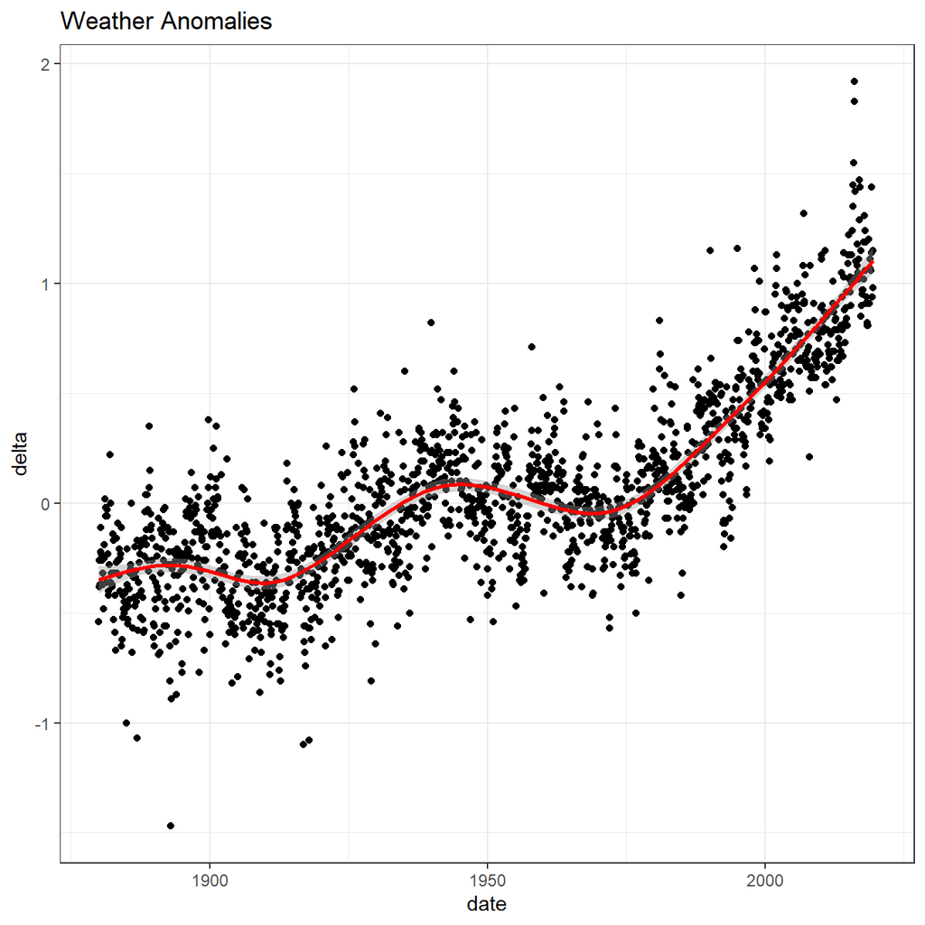

```r
tidyweather <- tidyweather %>%
  mutate(date = ymd(paste(as.character(Year), Month, "1")),
         month = month(date, label=TRUE),
         year = year(date))

ggplot(tidyweather, aes(x=date, y = delta))+
  geom_point()+
  geom_smooth(color="red") +
  theme_bw() +
  labs (
    title = "Weather Anomalies"
  )
```

Is the effect of increasing temperature more pronounced in some months?

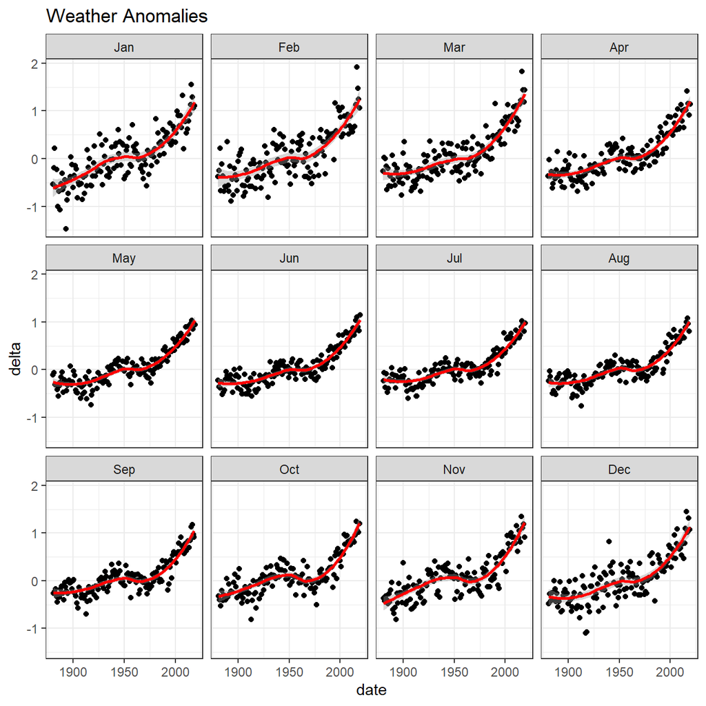

It is sometimes useful to group data into different time periods to study historical data. For example, we often refer to decades such as 1970s, 1980s, 1990s etc. to refer to a period of time. NASA calcuialtes a temperature anomaly, as difference form the base periof of 1951-1980. The code below creates a new data frame called `comparison` that groups data in five time periods: 1881-1920, 1921-1950, 1951-1980, 1981-2010 and 2011-present.

```r
comparison <- tidyweather %>%
  filter(Year>= 1881) %>%     #remove years prior to 1881
  #create new variable 'interval', and assign values based on criteria below:
  mutate(interval = case_when(
    Year %in% c(1881:1920) ~ "1881-1920",
    Year %in% c(1921:1950) ~ "1921-1950",
    Year %in% c(1951:1980) ~ "1951-1980",
    Year %in% c(1981:2010) ~ "1981-2010",
    TRUE ~ "2011-present"
  ))
```

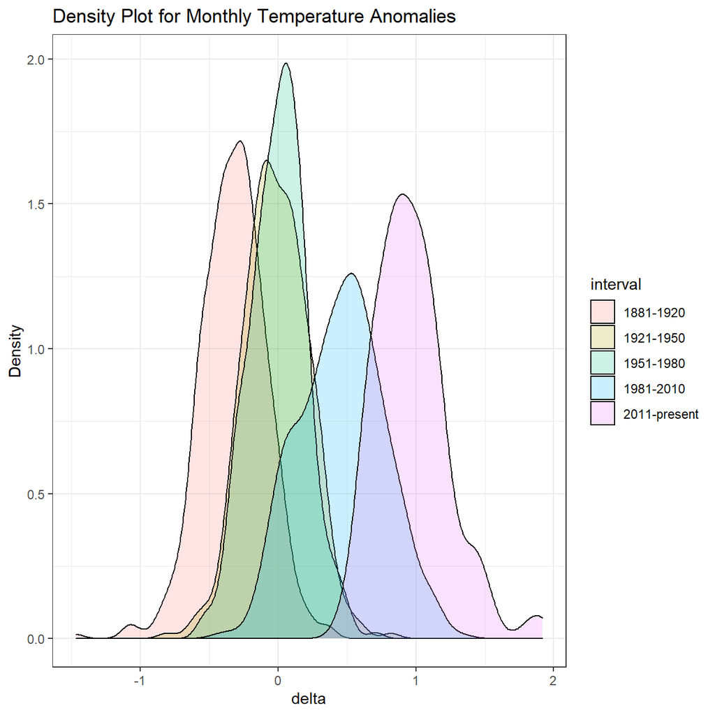

```r
ggplot(comparison, aes(x=delta, fill=interval))+
  geom_density(alpha=0.2) +   #density plot with tranparency set to 20%
  theme_bw() +                #theme
  labs (
    title = "Density Plot for Monthly Temperature Anomalies",
    y     = "Density"         #changing y-axis label to sentence case
  )
```

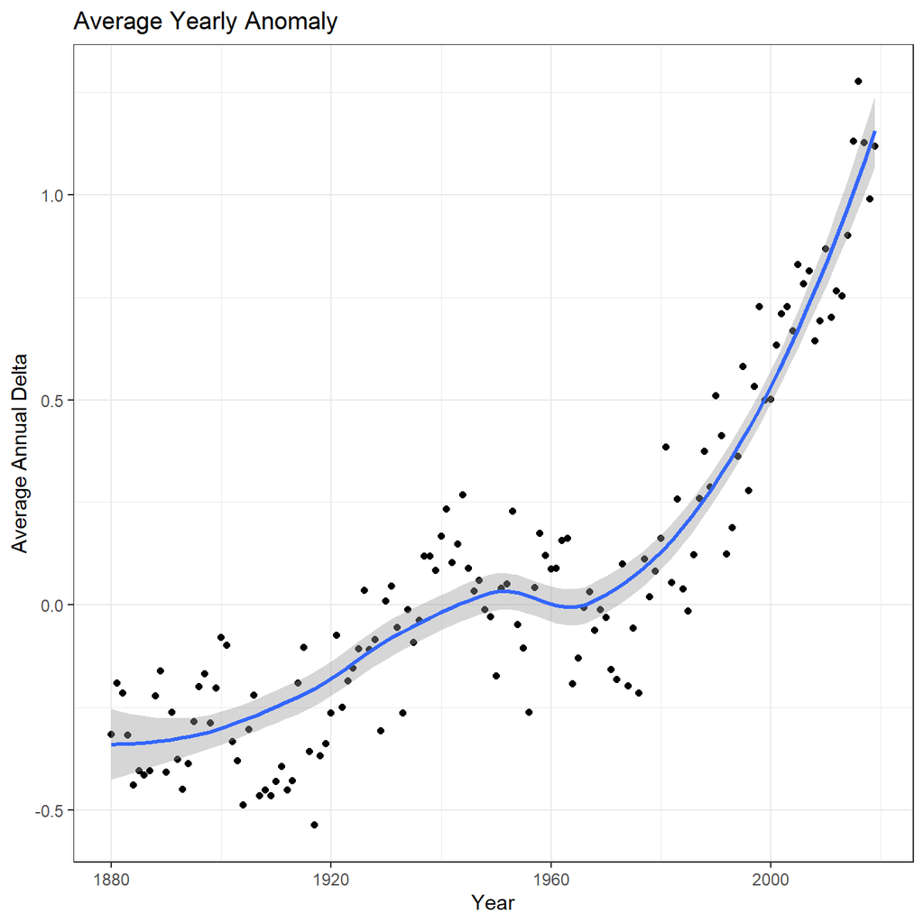

```r
#creating yearly averages
average_annual_anomaly <- tidyweather %>%
  group_by(Year) %>%   #grouping data by Year

  # creating summaries for mean delta
  # use `na.rm=TRUE` to eliminate NA (not available) values
  summarise(annual_average_delta = mean(delta, na.rm=TRUE))

#plotting the data:
ggplot(average_annual_anomaly, aes(x=Year, y= annual_average_delta))+
  geom_point() +

  #Fit the best fit line, using LOESS method
  geom_smooth() +

  #change to theme_bw() to have white background + black frame around plot
  theme_bw() +
  labs (
    title = "Average Yearly Anomaly",
    y     = "Average Annual Delta"
  )
```

## 1.2 Confidence Interval for `delta`

[NASA points out on their website](https://earthobservatory.nasa.gov/world-of-change/decadaltemp.php) that

> A one-degree global change is significant because it takes a vast amount of heat to warm all the oceans, atmosphere, and land by that much. In the past, a one- to two-degree drop was all it took to plunge the Earth into the Little Ice Age.

```r
formula_ci <- comparison %>%
  filter(interval=="2011-present",!is.na(delta)) %>%
  summarize(
    Average=mean(delta),
    Std_Dev=sd(delta),
    count=n(),
    Std_Err=Std_Dev/(sqrt(count)),
    Critical_Value=qt(0.95,count-1),
    Margin_Error=Std_Err*Critical_Value,
    Conf_Interval_Lower=Average-Margin_Error,
    Conf_Interval_Upper=Average+Margin_Error)
  # calculate lower/upper 95% CI


  # calculate summary statistics for temperature deviation (delta)
  # calculate mean, SD, count, SE, lower/upper 95% CI
  # what dplyr verb will you use?

#print out formula_CI
formula_ci
```

```
## # A tibble: 1 x 8
##   Average Std_Dev count Std_Err Critical_Value Margin_Error Conf_Interval_L~
##     <dbl>   <dbl> <int>   <dbl>          <dbl>        <dbl>            <dbl>
## 1   0.966   0.262   103  0.0259           1.66       0.0429            0.923
## # ... with 1 more variable: Conf_Interval_Upper <dbl>
```

```r
library(infer)
set.seed(1234)
boot.temperature<-comparison %>%
  filter(interval=="2011-present",!is.na(delta)) %>%
  specify(response=delta) %>%
  generate(reps=1000,type="bootstrap") %>%
  calculate(stat="mean")

CI<-boot.temperature %>%
  get_confidence_interval(level=0.95,type="percentile")

CI
```

```
## # A tibble: 1 x 2
##   lower_ci upper_ci
##      <dbl>    <dbl>
## 1    0.917     1.02
```

```r
# use the infer package to construct a 95% CI for delta
```

> What is the data showing us? Please type your answer after (and outside!) this blockquote. You have to explain what you have done, and the interpretation of the result. One paragraph max, please!

*First, we set the seed so R samples the same sample each time, so that our results will be the same when we (or someone else) reproduces them. Then, we filtered the data for the timeframe we wanted (2011-present), and cleared out any rows with empty delta values. We generated 1000 resamples of delta values with 103 observations in each, all in this specified time period with the sampling method boostrapping: sampling with replacement, meaning that if our sample space were a hat, whatever you take out of the hat, you have to put back into it before taking another sample out. Then we calculated the mean for 1000 samples, and from these sample means, we calculated the 95% confidence interval (displayed above) which means that there is a 95% chance that this confidence interval contains the true population mean.*

# 2 General Social Survey (GSS)

The [General Social Survey (GSS)](http://www.gss.norc.org/) gathers data on American society in order to monitor and explain trends in attitudes, behaviours, and attributes. Many trends have been tracked for decades, so one can see the evolution of attitudes, etc in American Society.

```r
gss <- read_csv(here::here("data", "smallgss2016.csv"),
                na = c("", "Don't know",
                       "No answer", "Not applicable"))
```

## 2.1 Instagram and Snapchat, by sex

Can we estimate the *population* proportion of Snapchat or Instagram users in 2016?

1. Create a new variable, `snap_insta` that is *Yes* if the respondent reported using any of Snapchat (`snapchat`) or Instagram (`instagrm`), and *No* if not. If the recorded value was NA for both of these questions, the value in your new variable should also be NA.

```r
library(dplyr)

gss_new<- gss %>%
  mutate(snap_insta = case_when(
    snapchat=="NA" & instagrm=="NA" ~ "NA",
    snapchat=="Yes"| instagrm=="Yes" ~ "Yes",
    TRUE ~ "No"))
```

2. Calculate the proportion of Yes’s for `snap_insta` among those who answered the question, i.e. excluding NAs.

```r
gss_new_proportion<- gss_new %>%
  filter(!is.na(snap_insta)) %>%
  group_by(sex) %>%
  mutate(user = case_when(
    snap_insta=="Yes" ~ 1,
    TRUE ~ 0)) %>%
  summarise(Total=length(user), Yes_answers=sum(user)) %>%
  mutate(Proportion=Yes_answers/Total)

gss_new_proportion
```

```
## # A tibble: 2 x 4
##   sex    Total Yes_answers Proportion
##   <chr>  <int>       <dbl>      <dbl>
## 1 Female  1591         322      0.202
## 2 Male    1276         192      0.150
```

3. Using the CI formula for proportions, please construct 95% CIs for men and women who used either Snapchat or Instagram

```r
gss_new_proportion %>%
  group_by(sex) %>%
  summarise(lower_95=Proportion-qt(0.975, Total-1)*sqrt((Proportion*(1-Proportion))/Total),
            upper_95=Proportion+qt(0.975, Total-1)*sqrt((Proportion*(1-Proportion))/Total))
```

```
## # A tibble: 2 x 3
##   sex    lower_95 upper_95
##   <chr>     <dbl>    <dbl>
## 1 Female    0.183    0.222
## 2 Male      0.131    0.170
```

## 2.2 Twitter, by education level

Can we estimate the *population* proportion of Twitter users by education level in 2016?.

There are 5 education levels in variable `degree` which, in ascneding order of years of education, are Lt high school, High School, Junior college, Bachelor, Graduate.

1. Turn `degree` from a character variable into a factor variable. Make sure the order is the correct one and that levels are not sorted alphabetically which is what R by default does.

```r
gss_clear <- gss %>%
  na_if("NA") %>%
  mutate(degree =
           factor(degree, levels=
                    c("Lt high school",
                      "High School",
                      "Junior college",
                      "Bachelor",
                      "Graduate"))) %>%
  filter(!is.na(degree))

class(gss_clear$degree)
```

```
## [1] "factor"
```

```r
str(gss_clear$degree)
```

```
##  Factor w/ 5 levels "Lt high school",..: 4 4 5 3 3 1 1 5 1 1 ...
```

2. Create a new variable, `bachelor_graduate` that is *Yes* if the respondent has either a `Bachelor` or `Graduate` degree. As before, if the recorded value for either was NA, the value in your new variable should also be NA.

```r
gss_degree<-gss_clear %>%
  mutate(bachelor_graduate = case_when(
    degree=="NA" ~ "NA",
    degree=="Bachelor"| degree=="Graduate" ~ "Yes",
    TRUE ~ "No"))
```

3. Calculate the proportion of `bachelor_graduate` who do (Yes) and who don’t (No) use twitter.

```r
gss_degree_proportion<- gss_degree %>%
  filter(!is.na(twitter)) %>%
  filter(bachelor_graduate=="Yes") %>%
  group_by(twitter) %>%
  summarise(Total=n()) %>%
  mutate(Proportion=Total/sum(Total))

gss_degree_proportion
```

```
## # A tibble: 2 x 3
##   twitter Total Proportion
##   <chr>   <int>      <dbl>
## 1 No        375      0.767
## 2 Yes       114      0.233
```

4. Using the CI formula for proportions, please construct two 95% CIs for `bachelor_graduate` vs whether they use (Yes) and don’t (No) use twitter.

```r
gss_degree_proportion %>%
  group_by(twitter) %>%
  summarise(lower_95=Proportion-qt(0.975, Total-1)*sqrt((Proportion*(1-Proportion))/Total),
            upper_95=Proportion+qt(0.975, Total-1)*sqrt((Proportion*(1-Proportion))/Total))
```

```
## # A tibble: 2 x 3
##   twitter lower_95 upper_95
##   <chr>      <dbl>    <dbl>
## 1 No         0.724    0.810
## 2 Yes        0.155    0.312
```

5. Do these two Confidence Intervals overlap? *Based on the answer to question 4, we can see that these Confidence Intervals, do not overlap*

## 2.3 Email usage

Can we estimate the *population* parameter on time spent on email weekly?

1. Create a new variable called `email` that combines `emailhr` and `emailmin` to reports the number of minutes the respondents spend on email weekly.

```r
gss_email<- gss %>%
  na_if("NA") %>%
  mutate(email=
           as.numeric(emailhr)*60+
           as.numeric(emailmin))

gss_email
```

```
## # A tibble: 2,867 x 8
##    emailmin emailhr snapchat instagrm twitter sex    degree         email
##    <chr>    <chr>   <chr>    <chr>    <chr>   <chr>  <chr>          <dbl>
##  1 0        12      <NA>     <NA>     <NA>    Male   Bachelor         720
##  2 30       0       No       No       No      Male   High school       30
##  3 <NA>     <NA>    No       No       No      Male   Bachelor          NA
##  4 10       0       <NA>     <NA>     <NA>    Female High school       10
##  5 <NA>     <NA>    Yes      Yes      No      Female Graduate          NA
##  6 0        2       No       Yes      No      Female Junior college   120
##  7 0        40      <NA>     <NA>     <NA>    Male   High school     2400
##  8 <NA>     <NA>    Yes      Yes      No      Female High school       NA
##  9 0        0       <NA>     <NA>     <NA>    Male   High school        0
## 10 <NA>     <NA>    No       No       No      Male   Junior college    NA
## # ... with 2,857 more rows
```

2. Visualise the distribution of this new variable. Find the mean and the median number of minutes respondents spend on email weekly. Is the mean or the median a better measure of the typical amoung of time Americans spend on email weekly? Why?

```r
library(ggplot2)

gss_stats<-gss_email %>%
  select(email) %>%
  filter(!is.na(email)) %>%
  summarise(Average=mean(email),Median=median(email))

gss_stats
```

```
## # A tibble: 1 x 2
##   Average Median
##     <dbl>  <dbl>
## 1    417.    120
```

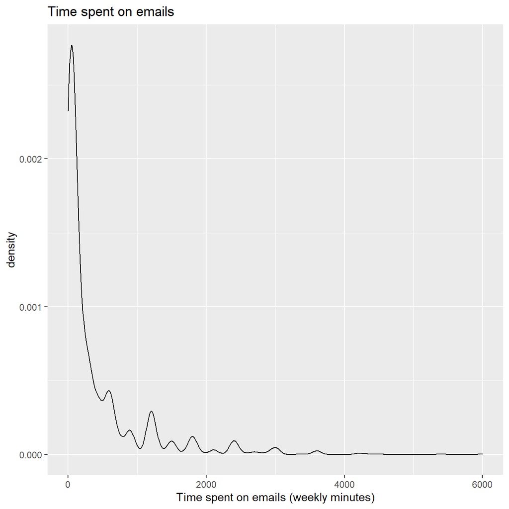

```r
gss_email %>%
  filter(!is.na(email)) %>%
ggplot(aes(x=email))+
  geom_density()+
  labs(title="Time spent on emails")+
  xlab("Time spent on emails (weekly minutes)")
```

```r
gss_email
```

```
## # A tibble: 2,867 x 8
##    emailmin emailhr snapchat instagrm twitter sex    degree         email
##    <chr>    <chr>   <chr>    <chr>    <chr>   <chr>  <chr>          <dbl>
##  1 0        12      <NA>     <NA>     <NA>    Male   Bachelor         720
##  2 30       0       No       No       No      Male   High school       30
##  3 <NA>     <NA>    No       No       No      Male   Bachelor          NA
##  4 10       0       <NA>     <NA>     <NA>    Female High school       10
##  5 <NA>     <NA>    Yes      Yes      No      Female Graduate          NA
##  6 0        2       No       Yes      No      Female Junior college   120
##  7 0        40      <NA>     <NA>     <NA>    Male   High school     2400
##  8 <NA>     <NA>    Yes      Yes      No      Female High school       NA
##  9 0        0       <NA>     <NA>     <NA>    Male   High school        0
## 10 <NA>     <NA>    No       No       No      Male   Junior college    NA
## # ... with 2,857 more rows
```

3. Using the `infer` package, calculate a 95% bootstrap confidence interval for the mean amount of time Americans spend on email weekly. Interpret this interval in context of the data, reporting its endpoints in “humanized” units (e.g. instead of 108 minutes, report 1 hr and 8 minutes). If you get a result that seems a bit odd, discuss why you think this might be the case.

```r
library(infer)

boot.emails <- gss_email %>%

  na.omit(email) %>%

  specify(response = email) %>%

  generate(reps = 1000, type = "bootstrap") %>%

  calculate(stat = "mean")

percentile_ci <- boot.emails %>%
  get_confidence_interval(level = 0.95, type = "percentile")

percentile_ci_new_lower_hour <- percentile_ci$lower_ci%/%60
percentile_ci_new_lower_minute <- percentile_ci$lower_ci%/%60
percentile_ci_new_upper_hour <- percentile_ci$upper_ci%/%60
percentile_ci_new_upper_minute <- percentile_ci$upper_ci%/%60

paste(percentile_ci_new_lower_hour, "hours and",
      format(round(percentile_ci_new_lower_minute),
             nsmall = 0), "minutes")
```

[output not shown]

```r
paste(percentile_ci_new_upper_hour, "hours and",
      format(round(percentile_ci_new_upper_minute),
             nsmall = 0), "minutes")
```

[output not shown]

```r
# use the infer package to construct a 95% CI for delta
```

4. Would you expect a 99% confidence interval to be wider or narrower than the interval you calculated above? Explain your reasoning.

*Wider, as the margin of error would be increased.*

# 3 Trump’s Approval Margins

As we saw in class, fivethirtyeight.com has detailed data on [all polls that track the president’s approval](https://projects.fivethirtyeight.com/trump-approval-ratings)

```r
# Import approval polls data
approval_polllist <- read_csv(here::here('data', 'approval_polllist.csv'))

# or directly off fivethirtyeight website
# approval_polllist <- read_csv('https://projects.fivethirtyeight.com/trump-approval-data/approval_polllist.csv')

glimpse(approval_polllist)
```

```
## Rows: 15,619
## Columns: 22
## $ president           <chr> "Donald Trump", "Donald Trump", "Donald Trump",...
## $ subgroup            <chr> "All polls", "All polls", "All polls", "All pol...
## $ modeldate           <chr> "9/27/2020", "9/27/2020", "9/27/2020", "9/27/20...
## $ startdate           <chr> "1/20/2017", "1/20/2017", "1/20/2017", "1/21/20...
## $ enddate             <chr> "1/22/2017", "1/22/2017", "1/24/2017", "1/23/20...
## $ pollster            <chr> "Gallup", "Morning Consult", "Ipsos", "Gallup",...
## $ grade               <chr> "B", "B/C", "B-", "B", "B-", "C+", "B+", "B", "...
## $ samplesize          <dbl> 1500, 1992, 1632, 1500, 1651, 1500, 1190, 1500,...
## $ population          <chr> "a", "rv", "a", "a", "a", "lv", "rv", "a", "lv"...
## $ weight              <dbl> 0.262, 0.680, 0.153, 0.243, 0.142, 0.200, 1.514...
## $ influence           <dbl> 0, 0, 0, 0, 0, 0, 0, 0, 0, 0, 0, 0, 0, 0, 0, 0,...
## $ approve             <dbl> 45.0, 46.0, 42.1, 45.0, 42.3, 57.0, 36.0, 46.0,...
## $ disapprove          <dbl> 45.0, 37.0, 45.2, 46.0, 45.8, 43.0, 44.0, 45.0,...
## $ adjusted_approve    <dbl> 45.7, 45.3, 43.2, 45.7, 43.4, 51.5, 37.6, 46.7,...
## $ adjusted_disapprove <dbl> 43.6, 38.3, 43.9, 44.6, 44.5, 44.5, 42.8, 43.6,...
## $ multiversions       <chr> NA, NA, NA, NA, NA, NA, NA, NA, NA, NA, NA, NA,...
## $ tracking            <lgl> TRUE, NA, TRUE, TRUE, TRUE, TRUE, NA, TRUE, TRU...
## $ url                 <chr> "http://www.gallup.com/poll/201617/gallup-daily...
## $ poll_id             <dbl> 49253, 49249, 49426, 49262, 49425, 49266, 49260...
## $ question_id         <dbl> 77265, 77261, 77599, 77274, 77598, 77278, 77272...
## $ createddate         <chr> "1/23/2017", "1/23/2017", "3/1/2017", "1/24/201...
## $ timestamp           <chr> "00:45:20 27 Sep 2020", "00:45:20 27 Sep 2020",...
```

```r
# Use `lubridate` to fix dates, as they are given as characters.
```

## 3.1 Create a plot

What I would like you to do is to calculate the average net approval rate (approve- disapprove) for each week since he got into office. I want you plot the net approval, along with its 95% confidence interval.

You can facet by year, and add an orange line at zero. Your plot should look like this:

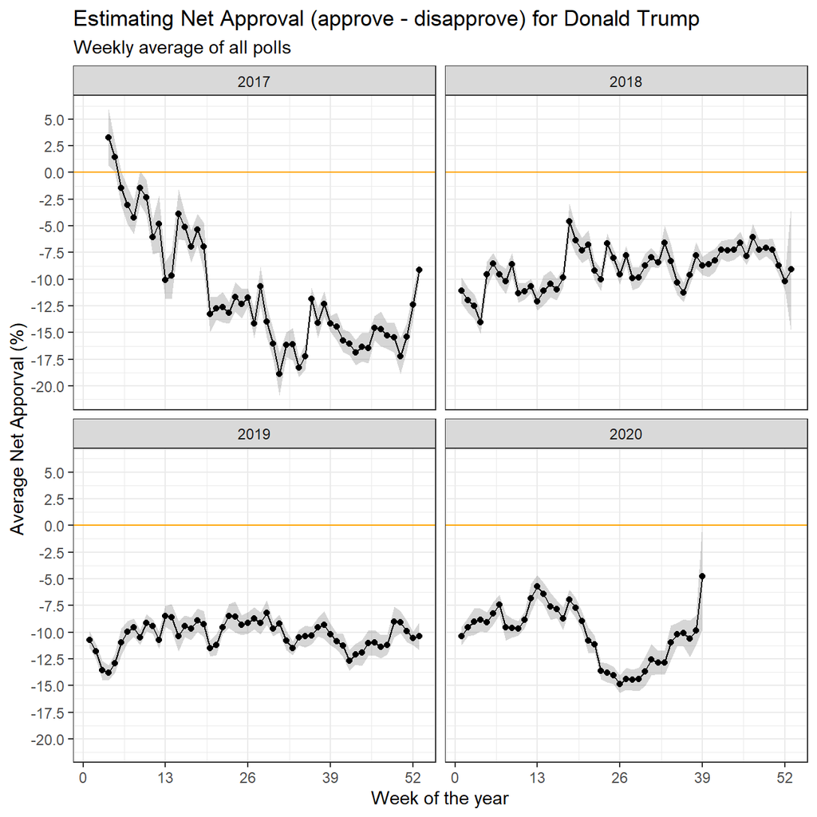

```
## # A tibble: 195 x 9
## # Groups:   Year [4]
##     Year  Week Average_net_app~  Stdv Critical_value    SE Margin_error      Low
##    <dbl> <dbl>            <dbl> <dbl>          <dbl> <dbl>        <dbl>    <dbl>
##  1  2017     4             3.30  5.27           1.78 1.46          2.61   0.694
##  2  2017     5             1.45  3.37           1.74 0.794         1.38   0.0716
##  3  2017     6            -1.47  4.54           1.71 0.927         1.59  -3.06
##  4  2017     7            -3.08  5.14           1.71 1.03          1.76  -4.83
##  5  2017     8            -4.21  4.48           1.71 0.915         1.57  -5.78
##  6  2017     9            -1.43  4.25           1.72 0.906         1.56  -2.99
##  7  2017    10            -2.34  4.98           1.71 0.977         1.67  -4.01
##  8  2017    11            -6.05  4.75           1.71 0.950         1.62  -7.68
##  9  2017    12            -4.81  7.71           1.71 1.54          2.64  -7.45
## 10  2017    13           -10.1   5.01           1.71 1.00          1.71 -11.8
## # ... with 185 more rows, and 1 more variable: High <dbl>
```

## 3.2 Compare Confidence Intervals

Compare the confidence intervals for `week 15` (6-12 April 2020) and `week 34` (17-23 August 2020). Can you explain what’s going on? One paragraph would be enough.

*The confidence interval in week 34 is wider than in week 15, which means that Trump’s approval rating had a bigger dispersion from 17-23 August, than from 6-12 April. This shift may have occurred due to the way Trump has handled the Coronavirus pandemic, and also George Floyd’s death, that led to several Black Lives Matter Movement’s protests.*

# 4 Gapminder revisited

Recall the `gapminder` data frame from the gapminder package. That data frame contains just six columns from the larger [data in Gapminder World](https://www.gapminder.org/data/).

```r
# load gapminder HIV data
hiv <- read_csv(here::here("data","adults_with_hiv_percent_age_15_49.csv"))
life_expectancy <- read_csv(here::here("data","life_expectancy_years.csv"))

# get World bank data using wbstats
indicators <- c("SP.DYN.TFRT.IN","SE.PRM.NENR", "SH.DYN.MORT", "NY.GDP.PCAP.KD")


library(wbstats)

worldbank_data <- wb_data(country="countries_only", #countries only- no aggregates like Latin America, Europe, etc.
                          indicator = indicators,
                          start_date = 1960,
                          end_date = 2016)

# get a dataframe of information regarding countries, indicators, sources, regions, indicator topics, lending types, income levels,  from the World Bank API
countries <-  wbstats::wb_cachelist$countries
```

You have to join the 3 dataframes (life_expectancy, worldbank_data, and HIV) into one. You may need to tidy your data first and then perform [join operations](http://r4ds.had.co.nz/relational-data.html). Think about what type makes the most sense **and explain why you chose it**.

```r
#Cleaning the Data

#Narrowing the scope of the data from 1990 to 2011, since HIV data is only available from 1990 to 2011
life_expectancy1 <- life_expectancy %>%
  na.omit %>%
  select("country", c("1990":"2011")) %>%
  pivot_longer(c("1990":"2011"),
               names_to="year",
               values_to="life_exp")

hiv1 <- hiv %>%
  drop_na("1990") %>%
  select("country",c("1990":"2011")) %>%
  pivot_longer(c("1990":"2011"),
               names_to="year",
               values_to="hiv")

#Combing the HIV and life_expectancy data sets by country,year
life_exp_hiv <- life_expectancy1 %>%
  left_join(hiv1,by = c("country","year")) %>%
  mutate(year = as.numeric(year))

#Extracting country code and region code from the country dataset
countries1 <- countries %>%
  select(c("iso3c","country","region_iso3c","region"))

#Adding thee country and region code to the lfe_expectancy_hiv dataset
life_exp_hiv <- life_exp_hiv %>%
  left_join(countries1, by = "country")

#Joining the world bank data set to the life expectancy dataset by country code
life_exp_hiv_worldbank <- life_exp_hiv %>%
  left_join(worldbank_data, by= c("iso3c", "year" = "date")) %>%
  filter(!is.na(iso3c)) %>%
  rename(gdp_percap = NY.GDP.PCAP.KD,
         school_enrollment = SE.PRM.NENR,
         mortality_rate = SH.DYN.MORT,
         fertility_rate = SP.DYN.TFRT.IN)

glimpse(worldbank_data)
```

```
## Rows: 12,369
## Columns: 8
## $ iso2c          <chr> "AW", "AW", "AW", "AW", "AW", "AW", "AW", "AW", "AW"...
## $ iso3c          <chr> "ABW", "ABW", "ABW", "ABW", "ABW", "ABW", "ABW", "AB...
## $ country        <chr> "Aruba", "Aruba", "Aruba", "Aruba", "Aruba", "Aruba"...
## $ date           <dbl> 1960, 1961, 1962, 1963, 1964, 1965, 1966, 1967, 1968...
## $ NY.GDP.PCAP.KD <dbl> NA, NA, NA, NA, NA, NA, NA, NA, NA, NA, NA, NA, NA, ...
## $ SE.PRM.NENR    <dbl> NA, NA, NA, NA, NA, NA, NA, NA, NA, NA, NA, NA, NA, ...
## $ SH.DYN.MORT    <dbl> NA, NA, NA, NA, NA, NA, NA, NA, NA, NA, NA, NA, NA, ...
## $ SP.DYN.TFRT.IN <dbl> 4.82, 4.66, 4.47, 4.27, 4.06, 3.84, 3.62, 3.42, 3.23...
```

```r
glimpse(life_exp_hiv)
```

```
## Rows: 4,048
## Columns: 7
## $ country      <chr> "Afghanistan", "Afghanistan", "Afghanistan", "Afghanis...
## $ year         <dbl> 1990, 1991, 1992, 1993, 1994, 1995, 1996, 1997, 1998, ...
## $ life_exp     <dbl> 52.6, 52.4, 52.9, 53.1, 52.7, 53.3, 53.8, 53.7, 52.8, ...
## $ hiv          <dbl> NA, NA, NA, NA, NA, NA, NA, NA, NA, NA, NA, NA, NA, NA...
## $ iso3c        <chr> "AFG", "AFG", "AFG", "AFG", "AFG", "AFG", "AFG", "AFG"...
## $ region_iso3c <chr> "SAS", "SAS", "SAS", "SAS", "SAS", "SAS", "SAS", "SAS"...
## $ region       <chr> "South Asia", "South Asia", "South Asia", "South Asia"...
```

1. What is the relationship between HIV prevalence and life expectancy? Generate a scatterplot with a smoothing line to report your results. You may find faceting useful

*Base on the graph below, we can see that the HIV prevalence and life expectancy are inversely related. The lower the prevalence of HIV in a country, the higher the life expectancy while on the flip side, the higher the prevalence of HIV, the lower the life expectancy. This relationship makes sense as HIV is one of the highest causes of mortality in the world and hence a person’s life expectancy would radically decrease should they contract HIV.*

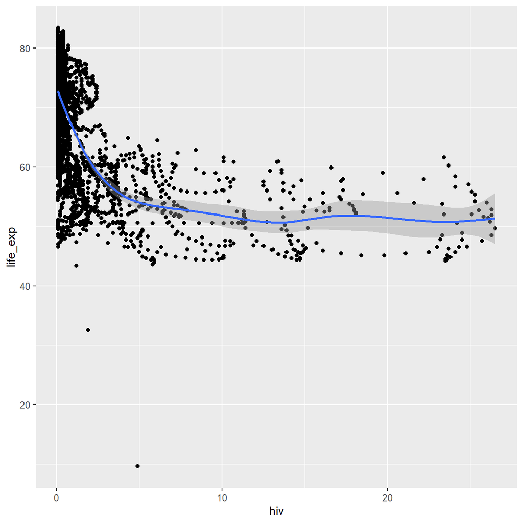

```r
life_exp_hiv_plot <- life_exp_hiv_worldbank %>%
  ggplot(aes(x=hiv,y=life_exp,))+
  geom_point()+
  geom_smooth()
life_exp_hiv_plot
```

2. What is the relationship between fertility rate and GDP per capita? Generate a scatterplot with a smoothing line to report your results. You may find facetting by region useful

*The overall relationship between fertility rate and GDP per capita is that the lower the GDP per capita, the higher the fertility rate. This could be explained due to the fact that the those with a lower income may not be able to afford contraceptives and hence they have a higher birth rate per woman. This trend continues to around $50,000, when the trend reverses and there is a slight increase in the fertility rate as GDP per capita increases. This could be due to the fact that the higher your income, the more likely you would be able to afford healthcare and hence be able to increase ones fertility.*

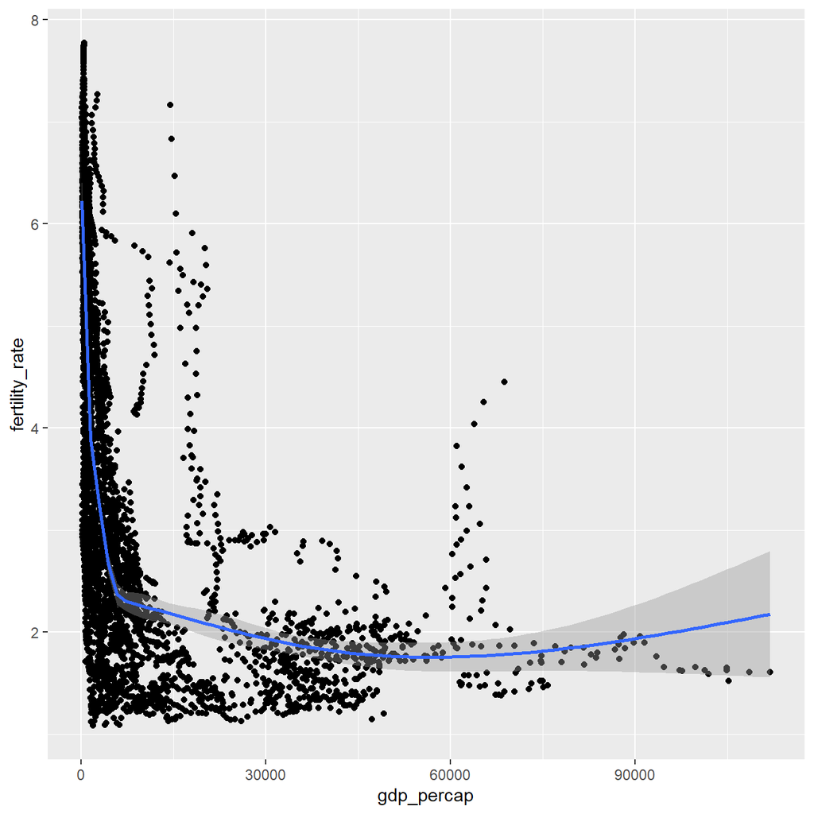

```r
fertility_gdp_plot <- life_exp_hiv_worldbank %>%
  ggplot(aes(x=gdp_percap,y=fertility_rate))+
  geom_point()+
  geom_smooth()

fertility_gdp_plot
```

3. Which regions have the most observations with missing HIV data? Generate a bar chart (`geom_col()`), in descending order.

[figure not shown]

```r
#Filtering the HIV columns to only NAs

hiv_na <- life_exp_hiv_worldbank %>%
  group_by(region) %>%
  summarise(count_na=sum(is.na(hiv))) %>%
  arrange(desc(count_na))


hiv_na_plot <- hiv_na %>%
  ggplot(aes(x=reorder(region,count_na),y=count_na))+
  geom_col()+
  coord_flip()+
  labs(x="",y="Count",title="Which country has the most missing HIV data?")

hiv_na_plot
```

5. Is there a relationship between primary school enrollment and fertility rate?

*There is a relationship between primary school enrollment and fertility rate. The higher the primary school enrollment, the lower the fertility rate. This could be explained by a variety of factors. For one, an increase in enrollment would mean less children are out of school and hence lower the chances of child marriages which in turn would decrease the fertility rate. Furthermore, an increase in enrollment would also mean an increase in education and hence greater prevalence of contraceptives could be used to lower the fertility rate.*

*At the same time, the fertility rate could also affect the primary school enrollment. With a higher fertility rate, which is most commonly found in less economically well of communities, this could also mean a diminishing ability to afford primary school education with every increase in children. This would mean as families have more kids, they would be less likely to afford to send their children to school and hence a decrease in primary school enrollment in these communities*.

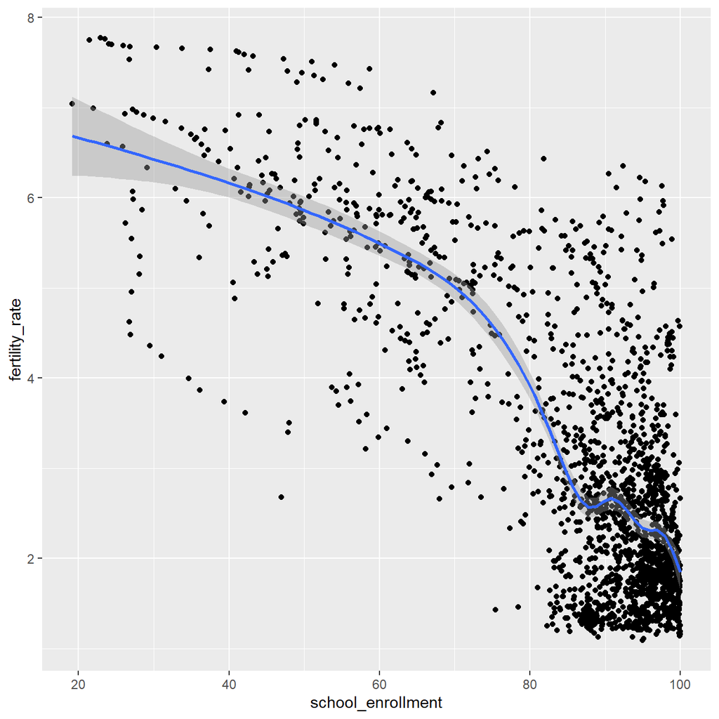

```r
enrollment_fertility_plot <- life_exp_hiv_worldbank %>%
  ggplot(aes(x=school_enrollment, y= fertility_rate))+
  geom_point()+
  geom_smooth()

enrollment_fertility_plot
```

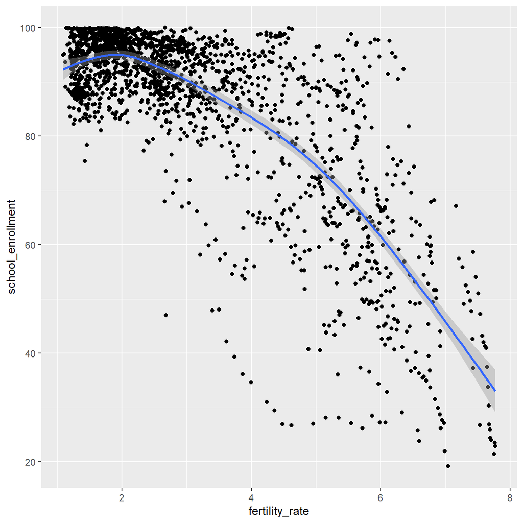

```r
fertility_enrollment_plot <- life_exp_hiv_worldbank %>%
  ggplot(aes(y=school_enrollment, x= fertility_rate))+
  geom_point()+
  geom_smooth()

fertility_enrollment_plot
```

# 5 Challenge 1: CDC COVID-19 Public Use Data

Let us revisit the [CDC Covid-19 Case Surveillance Data](https://data.cdc.gov/Case-Surveillance/COVID-19-Case-Surveillance-Public-Use-Data/vbim-akqf).

```r
# file contains 11 variables and 3.66m rows and is well over 380Mb.
# It will take time to download

# URL link to CDC to download data
url <- "https://data.cdc.gov/api/views/vbim-akqf/rows.csv?accessType=DOWNLOAD"

covid_data <- vroom::vroom(url)%>% # If vroom::vroom(url) doesn't work, use read_csv(url)
  clean_names()
```

Given the data we have, I would like you to produce two graphs that show death % rate:

1. by age group, sex, and whether the patient had co-morbidities or not
2. by age group, sex, and whether the patient was admited to Intensive Care Unit (ICU) or not.

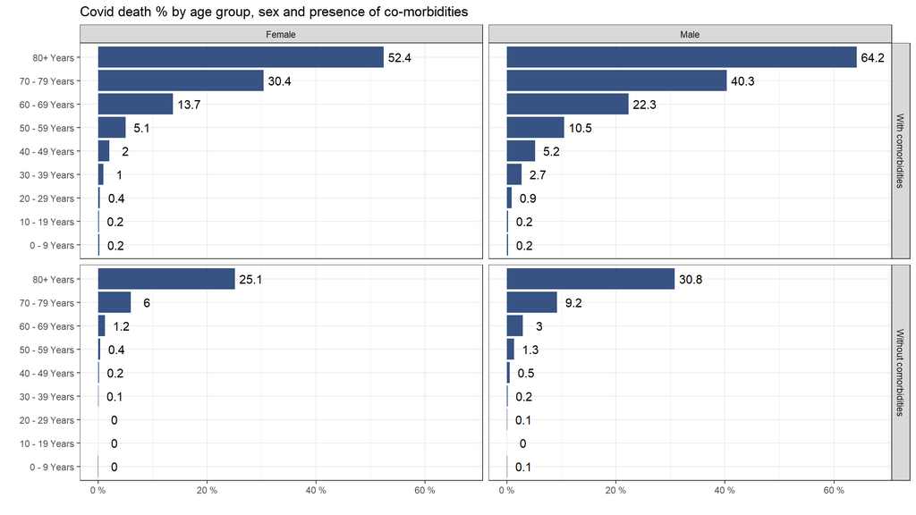

```r
# Filter and summarize count, for grouped data, with death criteria
grouped_med_death <- covid_data %>%
  filter(medcond_yn %in% c("Yes", "No"),        # Get rid of "Unknown" or "Missing" medcond_yn
         death_yn %in% c("Yes", "No"),          # Get rid of "Missing" death_yn
         death_yn != "Unknown",                 # Get rid of "Unknown" death_yn
         sex %in% c("Male", "Female"),          # Get rid of sex other than "Male" and "Female"
         age_group != "Unknown") %>%            # Get rid of age_group "Unknown"
  group_by(age_group, sex, medcond_yn, death_yn) %>%           # Group, with "Yes" or "No" as separate categories for death_yn
  summarise(N=n())                              # Obtain count for combinations of categories

# Filter and summarize count, for grouped data, without death criteria
grouped_med <- covid_data %>%
  filter(medcond_yn %in% c("Yes", "No"),
         death_yn %in% c("Yes", "No"),
         death_yn != "Unknown",
         sex %in% c("Male", "Female"),
         age_group != "Unknown") %>%
  group_by(age_group, sex, medcond_yn) %>%                     # Group, regardless of "Yes" or "No" for death_yn
  summarise(TN=n())

# Join categorical count and total count, calculate death rate
plot_comorbidities <- grouped_med_death %>%
  left_join(grouped_med, by = c("age_group", "sex", "medcond_yn")) %>%         # Present total count next to sub-count
  mutate(death_rate = N / TN * 100,                                                    # Create new column of calculated percentage of total
         medcond_yn = factor(medcond_yn,                                               # Factorize and rename medcond_yn feature
                             levels = c("Yes", "No"),
                             labels = c("With comorbidities",
                                        "Without comorbidities"))) %>%
  filter(death_yn == "Yes")      # Only use death_rate (not non-death rate) before plotting

# Plot
ggplot(plot_comorbidities, aes(x = age_group, y = death_rate)) +               # Specify data and axes
  geom_col(fill = "#365383") +                                                    # Specify chart style (bar) and fill color
  geom_text(mapping = aes(y = death_rate + 3, label = round(death_rate,1)), size = 4) +  # Specify data labels and their positions
  coord_flip() +                                                               # Flip axis
  facet_grid(medcond_yn ~ sex) +                                               # Create a grid format (vertical ~ horizontal)
  labs(x="",
       y = "",
       title = "Covid death % by age group, sex and presence of co-morbidities") +
  scale_y_continuous(breaks = seq(0, 60, 20),
                     labels = paste(seq(0, 60, 20), "%")) +
  theme_bw()
```

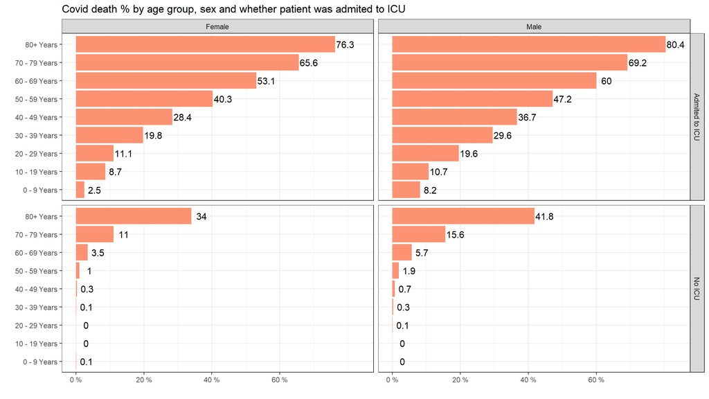

[figure not shown]

[figure not shown]

```r
#################################################################

# Filter and summarize count, for grouped data, with death criteria
grouped_icu_death <- covid_data %>%
  filter(icu_yn %in% c("Yes", "No"),
         death_yn %in% c("Yes", "No"),
         sex %in% c("Male", "Female"),
         age_group != "Unknown") %>%
  group_by(age_group, sex, icu_yn, death_yn) %>%
  summarise(N=n())

# Filter and summarize count, for grouped data, without death criteria
grouped_icu <- covid_data %>%
  filter(icu_yn %in% c("Yes", "No"),
         death_yn %in% c("Yes", "No"),
         sex %in% c("Male", "Female"),
         age_group != "Unknown") %>%
  group_by(age_group, sex, icu_yn) %>%
  summarise(TN=n())

# Join categorical count and total count, calculate death rate
plot_icu <- grouped_icu_death %>%
  left_join(grouped_icu, by = c("age_group", "sex", "icu_yn")) %>%
  mutate(death_rate = N / TN * 100,
         icu_yn = factor(icu_yn,
                         levels = c("Yes", "No"),
                         labels = c("Admited to ICU",
                                    "No ICU"))) %>%
  filter(death_yn == "Yes")

# Plot
ggplot(plot_icu, aes(x = age_group, y = death_rate)) +
  geom_col(fill = "#fc9272") +
  geom_text(mapping = aes(y = death_rate + 3, label = round(death_rate,1)), size = 4) +
  coord_flip() +
  facet_grid(icu_yn ~ sex) +
  labs(x="",
       y = "",
       title = "Covid death % by age group, sex and whether patient was admited to ICU") +
  scale_y_continuous(breaks = seq(0, 60, 20),
                     labels = paste(seq(0, 60, 20), "%")) +
  theme_bw()
```

Besides the graphs, make sure your code is easy to read and understand– imagine if you revisit this six months from now. you should be able to follow what you were doing!

# 6 Challenge 2: Excess rentals in TfL bike sharing

```r
url <- "https://data.london.gov.uk/download/number-bicycle-hires/ac29363e-e0cb-47cc-a97a-e216d900a6b0/tfl-daily-cycle-hires.xlsx"

# Download TFL data to temporary file
httr::GET(url, write_disk(bike.temp <- tempfile(fileext = ".xlsx")))
```

```
## Response [https://airdrive-secure.s3-eu-west-1.amazonaws.com/london/dataset/number-bicycle-hires/2020-09-18T09%3A06%3A54/tfl-daily-cycle-hires.xlsx?X-Amz-Algorithm=AWS4-HMAC-SHA256&X-Amz-Credential=AKIAJJDIMAIVZJDICKHA%2F20201004%2Feu-west-1%2Fs3%2Faws4_request&X-Amz-Date=20201004T214733Z&X-Amz-E…
##   Date: 2020-10-04 21:50
##   Status: 200
##   Content-Type: application/vnd.openxmlformats-officedocument.spreadsheetml.sheet
##   Size: 165 kB
## <ON DISK>  C:\Users\Nona\AppData\Local\Temp\RtmpwfInxw\file425c6aca23f0.xlsx
```

```r
# Use read_excel to read it as dataframe
bike0 <- read_excel(bike.temp,
                   sheet = "Data",
                   range = cell_cols("A:B"))

# change dates to get year, month, and week
bike <- bike0 %>%
  clean_names() %>%
  rename (bikes_hired = number_of_bicycle_hires) %>%
  mutate (year = year(day),
          month = lubridate::month(day, label = TRUE),
          week = isoweek(day))
```

We can easily create a facet grid that plots bikes hired by month and year.

**Below are two graphs we reproduced**

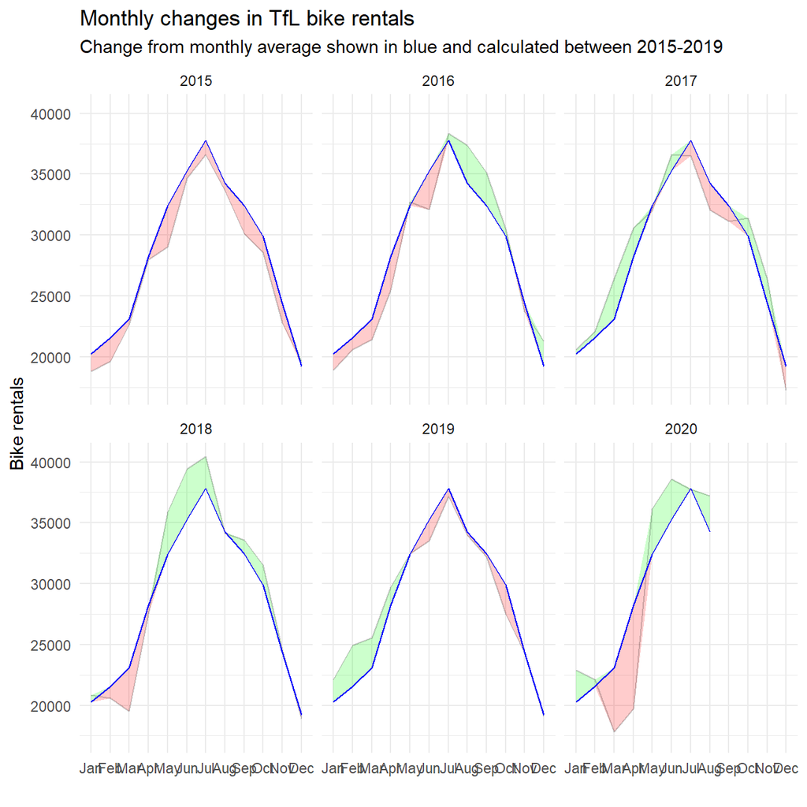

[figure not shown]

```r
#Getting monthly expected values
monthly_exp <- bike %>%
  filter(year %in% c("2015", "2016", "2017", "2018", "2019")) %>% #filtered by years to exclude 2020
  group_by(month) %>%
  summarize(monthly_mean = mean(bikes_hired))

#Getting monthly actual rents
monthly_rent <- bike %>%
  filter(year > 2014) %>%
  group_by(year, month) %>%
  summarize(real_rents = mean(bikes_hired))

#Merging the two data frames above to have one data frame wih all information and creating the variable excess rentals
monthly_rent_and_ex <- merge(x = monthly_rent, y = monthly_exp, by = "month", all.x=TRUE) %>%
  mutate(excess_rentals = real_rents - monthly_mean)


#plotting graphs
monthly_dist  <- ggplot(monthly_rent_and_ex, aes(y = monthly_mean, x = month, group =year)) +
  geom_ribbon(aes(ymin = ifelse(excess_rentals > 0, monthly_mean, real_rents), ymax = monthly_mean), fill = "red", alpha = 0.2) +
  geom_ribbon(aes(ymin = ifelse(excess_rentals < 0, monthly_mean, real_rents), ymax = monthly_mean), fill = "green", alpha = 0.2) +
  geom_line(aes(y = real_rents), alpha = 0.2) +
  geom_line(color = "blue", aes(y = monthly_mean, group = 1)) +
  labs(title = "Monthly changes in TfL bike rentals", subtitle = "Change from monthly average shown in blue and calculated between 2015-2019", y = "Bike rentals", x ="") +
  facet_wrap(~ year) +
  theme_minimal()


monthly_dist
```

The second one looks at percentage changes from the expected level of weekly rentals. The two grey shaded rectangles correspond to the second (weeks 14-26) and fourth (weeks 40-52) quarters.

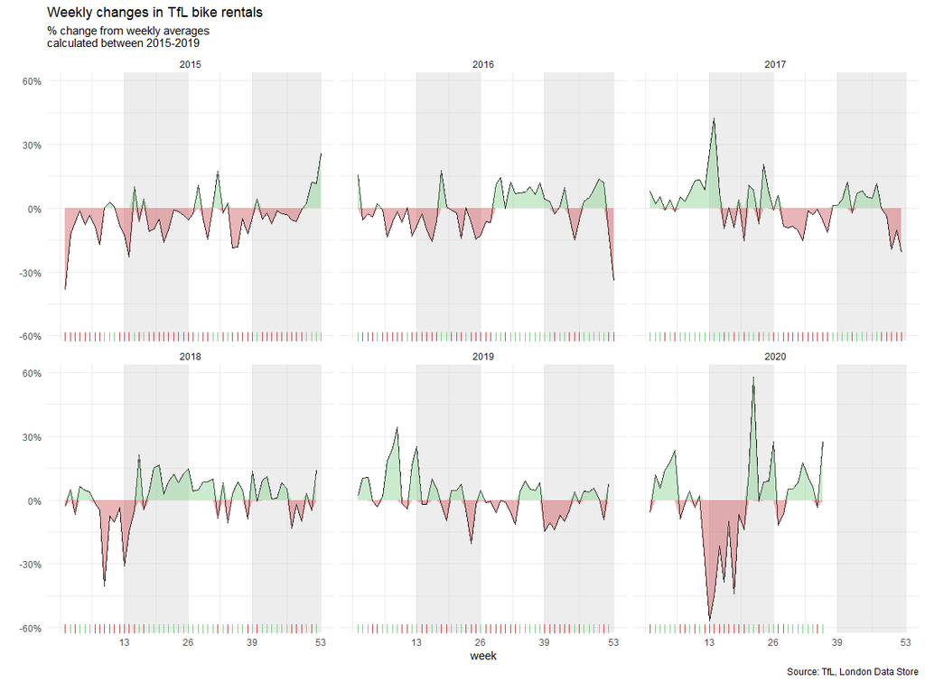

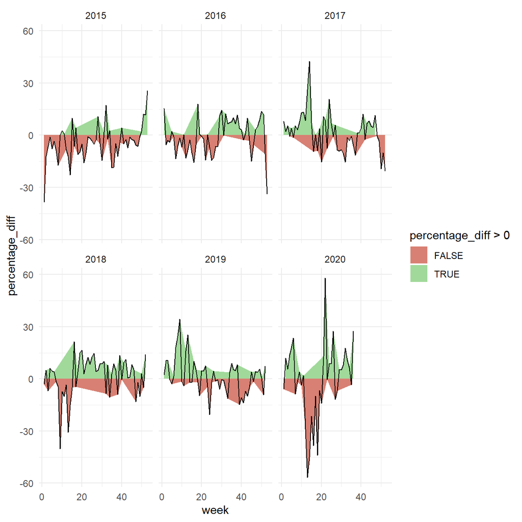

```r
#Getting weekly expected values
weekly_average_df <- bike %>%
  filter(year %in% c("2015", "2016", "2017", "2018", "2019")) %>% #filtered by years to exclude 2020
  group_by(week) %>%
  summarize(weekly_average = mean(bikes_hired))

#Getting weekly actual rents
weekly_real_df <- bike %>%
  filter(year > 2014) %>%
  group_by(year, week) %>%
  summarize(weekly_real = mean(bikes_hired))

#Merging the two data frames above to have one data frame with all information and creating the variable excess rentals
weekly_average_and_real_df <- merge(x = weekly_real_df, y = weekly_average_df, by = "week", all.x=TRUE) %>%
  mutate(excess_rentals = weekly_real - weekly_average) %>%
  mutate(percentage_diff = (excess_rentals/weekly_average)*100)

#Plotting the percentage difference per real rents per week and expected rents per week
weekly_plot <- ggplot(weekly_average_and_real_df, aes(x = week, y = percentage_diff)) +
  geom_ribbon(aes(ymin = 0, ymax = percentage_diff, fill = percentage_diff > 0))+
  geom_line(aes(y = percentage_diff)) +
  scale_fill_manual(values = c("#d88073", "#a1d99b")) +
  facet_wrap(~year) +
  theme_minimal()

weekly_plot
```

For both of these graphs, you have to calculate the expected number of rentals per week or month between 2015-2019 and then, see how each week/month of 2020 compares to the expected rentals. Think of the calculation `excess_rentals = actual_rentals - expected_rentals`.

Should you use the mean or the median to calculate your expected rentals? Why? *If we use the median, we can avoid outliers than can move our mean significantly towards one way, but in this case we chose the mean since the plot explicitly says “average”.*

# 7 Details

- Who did you collaborate with: Azmi Dzulkarnain, Beatriz Vala, Nona Velez, Andrea Gerards, Guillaume Borigite, Kris Wu
- Approximately how much time did you spend on this problem set: 50 hours
- What, if anything, gave you the most trouble: Understadning the geom_ribbon() function, the gapminder problem, and figure out how to format the plots to look the same way color-wise, axis spaces, and other aesthethic detai.s

**Please seek out help when you need it,** and remember the [15-minute rule](https://mam2021.netlify.app/syllabus/#the-15-minute-rule). You know enough R (and have enough examples of code from class and your readings) to be able to do this. If you get stuck, ask for help from others, post a question on Slack– and remember that I am here to help too!

> As a true test to yourself, do you understand the code you submitted and are you able to explain it to someone else?

# 8 Rubric

Check minus (1/5): Displays minimal effort. Doesn’t complete all components. Code is poorly written and not documented. Uses the same type of plot for each graph, or doesn’t use plots appropriate for the variables being analyzed.

Check (3/5): Solid effort. Hits all the elements. No clear mistakes. Easy to follow (both the code and the output).

Check plus (5/5): Finished all components of the assignment correctly and addressed both challenges. Code is well-documented (both self-documented and with additional comments as necessary). Used tidyverse, instead of base R. Graphs and tables are properly labelled. Analysis is clear and easy to follow, either because graphs are labeled clearly or you’ve written additional text to describe how you interpret the output.